# Mood Disorder & Suicidality Risk Group Cluster Characterizations

Sam A. Sievertsen

2025-01-29

## Review of Clustering Results and Selection of Optimal *k*

Results from the `risk_group_clustering` script suggest it is likely that optimal *k* = 5. Re-iterating the most important information here, this determination was made because the elbow plot suggests a natural elbow wherein reduction in total within sum of squares values levels off after *k* = 5 (*note*: a similar tapering is observed after *k* = 4, but the distinction between the two *k* values will be made in the discussion of the silhouette index results):

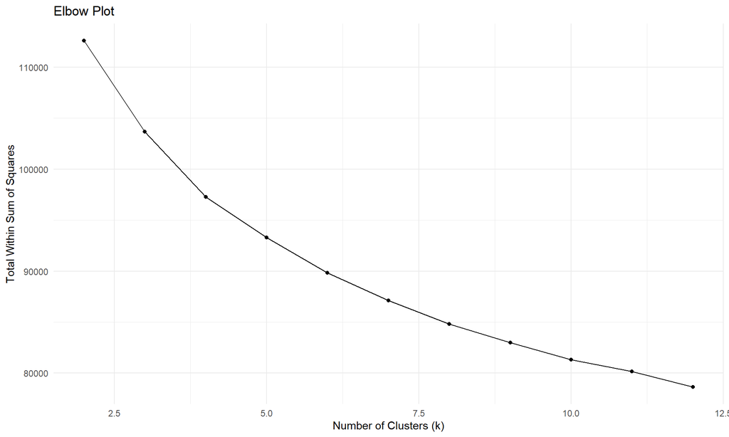

In addition to the elbow plot, wherein *k = 5* is observed to exhibit the qualities of an elbow, the *k* grouped mean silhouette scores indicate that *k = 5* is the third most optimal clustering solution (μ = 0.113; following *k = 4* closely, wherein μ = 0.123):

| k | Mean Silhouette Score |
| --- | --- |
| 2 | 0.32010389 |
| 3 | 0.10884709 |
| 4 | 0.12353260 |
| 5 | 0.11326346 |
| 6 | 0.08867170 |
| 7 | 0.07515127 |
| 8 | 0.09158811 |
| 9 | 0.03945798 |
| 10 | 0.04270715 |
| 11 | 0.03744811 |
| 12 | 0.03632500 |

At this point, despite the slightly greater reduction in total within sum of squares values, it is not evident whether *k = 5* is more optimal than *k = 4*. This becomes more clear, though, when we examine the density plot of silhouette scores at the individual subject within-cluster level:

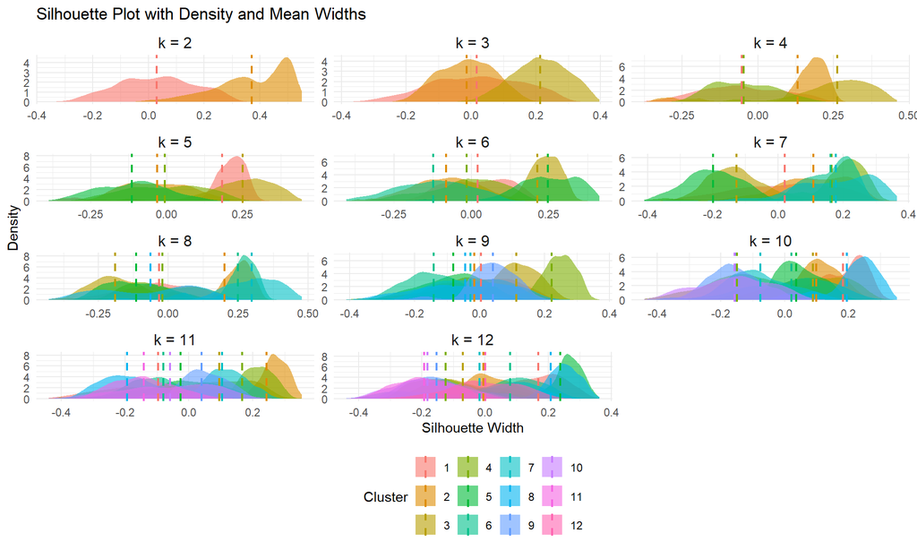

### Assessment of Current Results Using Huang Distance

At *k = 5*, the tight grouping of clusters about silhouette = 0.20 for clusters 1 and 3 and okay (albeit lower and more spread) performance of cluster 2 and 4 (about silhouette = 0) is superior to *k = 4*. Cluster 5 does not indicate good performance according to the silhouette index, but this limitation will be discussed below.

It should be noted that the silhouette index as it is currently used is likely not a great indicator of cluster separation/performance, given it tends to favor clustering solutions wherein separation of the categorical variables are prioritized over separation of the continuous variables (as is best done by the gower distance method). Given this bias, our determination of the optimal k value in this iteration of clustering is partially subjective in nature; and while this is acceptable for first round analyses to be submitted to SOBP, these results are tentative, and need to be reviewed more carefully considering:

- The inclusion of validation indices that provide indicators of within cluster performance (e.g., C index), cluster separation for both categorical and continuous data (e.g., point-biserial coefficient), and something like the weighted silhouette index which takes distance + variance of both types of data into account;
- Secondary considerations such as the stability of the clusters (e.g., assessed using stability_kproto()) and gap statistics; and
- Optimization of lambda parameters

prior to any publication/more widespread communication of statistical results derived using these clusters.

## Characterization of *k* = 5 Clusters

### Integration of Clusters Back Into Risk Variable Data

In order to best characterize the risk groups (i.e., according to their original risk variables on their native scale), we will first need to merge the clustered group values back into the original risk data:

```r
## Merge Cluster Group Values Back Into Original Data ##

#1. Extract the cluster assignment values from the kproto results
#1.1 Create a dataframe containing each subjects cluster value
subject_cluster_values <- as.data.frame(kproto_results[["k_5"]][["model"]][["cluster"]])

#1.2 Create a column containing each subjects ID
subject_cluster_values$src_subject_id <- row.names(subject_cluster_values)

#1.3 Clean the column names + retain columns of interest
subject_cluster_values <- subject_cluster_values %>%
  mutate(cluster = `kproto_results[["k_5"]][["model"]][["cluster"]]`) %>%
  dplyr::select(c(src_subject_id, cluster))

#2. Merge cluster values back into original data
clustered_risk_variable_data <- left_join(risk_variable_data, subject_cluster_values)

#3. Output the merged risk variable + cluster data
write.csv(clustered_risk_variable_data, "../../data/data_processed/clustered_risk_variable_data.csv", row.names = FALSE)
```

### Profiling the Risk Group Clusters According to Risk Variables

Now that cluster assignments have been merged into the original risk data, we can profile the different clusters according to each categorical (binary) risk variable:

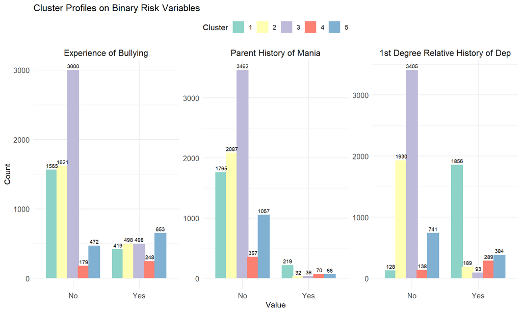

```r
## Characterize the Clusters According to Binary Risk Variables ##

#1. Create a bar chart for each binary variable
#1.1 Define the binary variables
binary_vars <- c("family_history_depression", "famhx_ss_momdad_ma_p", "bullying")

#1.2 Define variable descriptions
binary_variable_labels <- c(
  family_history_depression = "1st Degree Relative History of Dep",
  famhx_ss_momdad_ma_p = "Parent History of Mania",
  bullying = "Experience of Bullying"
)

#1.3 Wrangle data for plotting
binary_plot_data <- clustered_risk_variable_data %>%
  dplyr::select(cluster, family_history_depression, famhx_ss_momdad_ma_p, bullying) %>%
  pivot_longer(-cluster, names_to = "variable", values_to = "value") %>%
  group_by(cluster, variable, value) %>%
  summarise(count = n(), .groups = "drop")

#1.4 Create the binary variable plot
binary_plot <- binary_plot_data %>%
  ggplot(aes(x = as.factor(value), y = count, fill = as.factor(cluster))) +
  geom_bar(stat = "identity", position = position_dodge(width = 0.8)) +
  geom_text(aes(label = count),
            position = position_dodge(width = 0.8),
            vjust = -0.5,
            size = 2.5) +
  facet_wrap(
    ~variable,
    scales = "free_y",
    labeller = as_labeller(binary_variable_labels)
  ) +
  labs(x = "Value", y = "Count", fill = "Cluster",
       title = "Cluster Profiles on Binary Risk Variables") +
  scale_x_discrete(labels = c("0" = "No", "1" = "Yes")) +
  theme_minimal() +
  theme(strip.text = element_text(size = 12),
        axis.text = element_text(size = 10),
        legend.position = "top") +
  scale_fill_brewer(palette = "Set3")

#1.4 Print the binary values plot
print(binary_plot)
```

As well as profile the clusters according to each continuous risk variable:

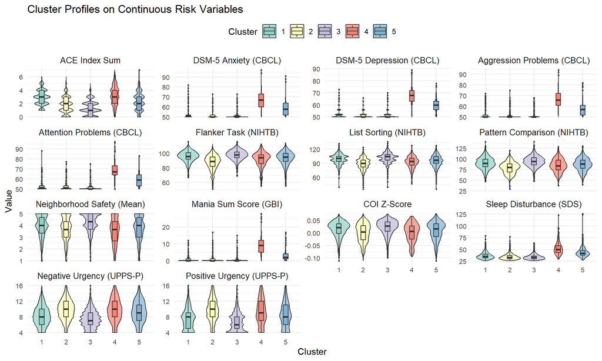

```r
## Characterize the Clusters According to Continuous Risk Variables ##

#1. Create a violin boxplot for each continuous variable
#1.1 Define the continuous variables and descriptions
continuous_vars <- c("cbcl_scr_dsm5_depress_t", "cbcl_scr_dsm5_anxdisord_t",
                     "cbcl_scr_syn_attention_t", "cbcl_scr_syn_aggressive_t",
                     "pgbi_p_ss_score", "upps_y_ss_negative_urgency",
                     "upps_y_ss_positive_urgency", "sds_p_ss_total",
                     "reshist_addr1_coi_z_coi_nat", "nsc_p_ss_mean_3_items",
                     "nihtbx_list_uncorrected", "nihtbx_flanker_uncorrected",
                     "nihtbx_pattern_uncorrected", "ACE_index_sum_score")

#1.2 Define labels for each continuous variable
continuous_variable_labels <- c(
  cbcl_scr_dsm5_depress_t = "DSM-5 Depression (CBCL)",
  cbcl_scr_dsm5_anxdisord_t = "DSM-5 Anxiety (CBCL)",
  cbcl_scr_syn_attention_t = "Attention Problems (CBCL)",
  cbcl_scr_syn_aggressive_t = "Aggression Problems (CBCL)",
  pgbi_p_ss_score = "Mania Sum Score (GBI)",
  upps_y_ss_negative_urgency = "Negative Urgency (UPPS-P)",
  upps_y_ss_positive_urgency = "Positive Urgency (UPPS-P)",
  sds_p_ss_total = "Sleep Disturbance (SDS)",
  reshist_addr1_coi_z_coi_nat = "COI Z-Score",
  nsc_p_ss_mean_3_items = "Neighborhood Safety (Mean)",
  nihtbx_list_uncorrected = "List Sorting (NIHTB)",
  nihtbx_flanker_uncorrected = "Flanker Task (NIHTB)",
  nihtbx_pattern_uncorrected = "Pattern Comparison (NIHTB)",
  ACE_index_sum_score = "ACE Index Sum"
)

#1.3 Wrangle data for plotting
continuous_plot_data <- clustered_risk_variable_data %>%
  dplyr::select(cluster, cbcl_scr_dsm5_depress_t,
                cbcl_scr_dsm5_anxdisord_t, cbcl_scr_syn_attention_t,
                cbcl_scr_syn_aggressive_t, pgbi_p_ss_score,
                upps_y_ss_negative_urgency, upps_y_ss_positive_urgency,
                sds_p_ss_total, reshist_addr1_coi_z_coi_nat,
                nsc_p_ss_mean_3_items, nihtbx_list_uncorrected,
                nihtbx_flanker_uncorrected, nihtbx_pattern_uncorrected,
                ACE_index_sum_score) %>%
  pivot_longer(-cluster, names_to = "variable", values_to = "value")

#1.4 Create the violin boxplot
continuous_plot <- continuous_plot_data %>%
  ggplot(aes(x = as.factor(cluster), y = value, fill = as.factor(cluster))) +
  geom_violin(trim = TRUE, alpha = 0.7) +
  geom_boxplot(width = 0.2, position = position_dodge(width = 0.9), outlier.size = 0.5) +
  facet_wrap(
    ~variable,
    scales = "free_y",
    labeller = as_labeller(continuous_variable_labels)
  ) +
  labs(x = "Cluster", y = "Value", fill = "Cluster",
       title = "Cluster Profiles on Continuous Risk Variables") +
  theme_minimal() +
  theme(strip.text = element_text(size = 10),
        axis.text = element_text(size = 8),
        legend.position = "top") +
  scale_fill_brewer(palette = "Set3")

#1.5 Print the continuous variable plot
print(continuous_plot)
```

```r
#2. Create a summary statistics table for the continuous variables
#2.1 Wrangle data for summary statistics
continuous_summary_data <- continuous_plot_data %>%
  group_by(cluster, variable) %>%
  summarize(
    mean = round(mean(value, na.rm = TRUE), 2),
    sd = round(sd(value, na.rm = TRUE), 2),
    median = round(median(value, na.rm = TRUE), 2),
    range = paste0(
      round(min(value, na.rm = TRUE), 2), " - ",
      round(max(value, na.rm = TRUE), 2)
    ),
    .groups = "drop"
  ) %>%
  mutate(variable = as_labeller(continuous_variable_labels)(variable))

#2.2 Create the summary statistics table
continuous_summary_data %>%
  kbl(col.names = c("Cluster", "Variable", "Mean", "SD", "Median", "Range"),
      caption = "Summary Statistics for Continuous Risk Variables by Cluster") %>%
  kable_styling(full_width = FALSE, bootstrap_options = c("striped", "hover", "condensed"))
```

Summary Statistics for Continuous Risk Variables by Cluster

| Cluster | Variable | Mean | SD | Median | Range |
| --- | --- | --- | --- | --- | --- |
| 1 | ACE Index Sum | 2.87 | 1.15 | 3.00 | 1 - 6 |
| 1 | DSM-5 Anxiety (CBCL) | 52.59 | 4.19 | 51.00 | 50 - 82 |
| 1 | DSM-5 Depression (CBCL) | 52.68 | 3.91 | 52.00 | 50 - 73 |
| 1 | Aggression Problems (CBCL) | 51.71 | 3.19 | 50.00 | 50 - 72 |
| 1 | Attention Problems (CBCL) | 52.76 | 4.01 | 51.00 | 50 - 88 |
| 1 | Flanker Task (NIHTB) | 95.76 | 7.16 | 96.00 | 67 - 116 |
| 1 | List Sorting (NIHTB) | 98.94 | 10.35 | 101.00 | 40 - 132 |
| 1 | Pattern Comparison (NIHTB) | 90.01 | 13.69 | 90.00 | 47 - 140 |
| 1 | Neighborhood Safety (Mean) | 3.89 | 0.94 | 4.00 | 1 - 5 |
| 1 | Mania Sum Score (GBI) | 0.74 | 1.40 | 0.00 | 0 - 12 |
| 1 | COI Z-Score | 0.01 | 0.03 | 0.02 | -0.11 - 0.08 |
| 1 | Sleep Disturbance (SDS) | 36.25 | 6.50 | 35.00 | 26 - 79 |
| 1 | Negative Urgency (UPPS-P) | 8.24 | 2.44 | 8.00 | 4 - 16 |
| 1 | Positive Urgency (UPPS-P) | 7.57 | 2.67 | 8.00 | 4 - 16 |
| 2 | ACE Index Sum | 1.69 | 1.24 | 2.00 | 0 - 6 |
| 2 | DSM-5 Anxiety (CBCL) | 51.49 | 2.86 | 50.00 | 50 - 73 |
| 2 | DSM-5 Depression (CBCL) | 51.40 | 2.54 | 50.00 | 50 - 66 |
| 2 | Aggression Problems (CBCL) | 51.19 | 2.61 | 50.00 | 50 - 75 |
| 2 | Attention Problems (CBCL) | 52.47 | 3.75 | 51.00 | 50 - 77 |
| 2 | Flanker Task (NIHTB) | 87.77 | 9.91 | 89.00 | 51 - 113 |
| 2 | List Sorting (NIHTB) | 89.43 | 11.96 | 90.00 | 36 - 124 |
| 2 | Pattern Comparison (NIHTB) | 79.03 | 13.30 | 80.00 | 30 - 120 |
| 2 | Neighborhood Safety (Mean) | 3.68 | 1.00 | 3.67 | 1 - 5 |
| 2 | Mania Sum Score (GBI) | 0.65 | 1.48 | 0.00 | 0 - 17 |
| 2 | COI Z-Score | 0.00 | 0.04 | 0.00 | -0.11 - 0.08 |
| 2 | Sleep Disturbance (SDS) | 33.88 | 5.38 | 33.00 | 26 - 77 |
| 2 | Negative Urgency (UPPS-P) | 9.78 | 2.56 | 10.00 | 4 - 16 |
| 2 | Positive Urgency (UPPS-P) | 9.73 | 2.85 | 10.00 | 4 - 16 |
| 3 | ACE Index Sum | 1.31 | 1.05 | 1.00 | 0 - 5 |
| 3 | DSM-5 Anxiety (CBCL) | 51.39 | 2.88 | 50.00 | 50 - 73 |
| 3 | DSM-5 Depression (CBCL) | 51.30 | 2.61 | 50.00 | 50 - 70 |
| 3 | Aggression Problems (CBCL) | 50.73 | 1.89 | 50.00 | 50 - 68 |
| 3 | Attention Problems (CBCL) | 51.36 | 2.54 | 50.00 | 50 - 75 |
| 3 | Flanker Task (NIHTB) | 97.82 | 6.50 | 98.00 | 69 - 116 |
| 3 | List Sorting (NIHTB) | 101.80 | 9.88 | 105.00 | 40 - 136 |
| 3 | Pattern Comparison (NIHTB) | 94.03 | 12.30 | 94.00 | 48 - 140 |
| 3 | Neighborhood Safety (Mean) | 4.21 | 0.78 | 4.33 | 1 - 5 |
| 3 | Mania Sum Score (GBI) | 0.35 | 0.93 | 0.00 | 0 - 15 |
| 3 | COI Z-Score | 0.02 | 0.03 | 0.03 | -0.1 - 0.08 |
| 3 | Sleep Disturbance (SDS) | 33.65 | 5.15 | 33.00 | 26 - 64 |
| 3 | Negative Urgency (UPPS-P) | 7.45 | 2.20 | 7.00 | 4 - 16 |
| 3 | Positive Urgency (UPPS-P) | 6.73 | 2.35 | 6.00 | 4 - 16 |
| 4 | ACE Index Sum | 3.20 | 1.43 | 3.00 | 0 - 7 |
| 4 | DSM-5 Anxiety (CBCL) | 67.59 | 10.07 | 67.00 | 50 - 97 |
| 4 | DSM-5 Depression (CBCL) | 67.34 | 6.89 | 68.00 | 50 - 89 |
| 4 | Aggression Problems (CBCL) | 67.13 | 8.64 | 66.00 | 50 - 94 |
| 4 | Attention Problems (CBCL) | 68.69 | 9.49 | 67.00 | 50 - 97 |
| 4 | Flanker Task (NIHTB) | 91.32 | 10.50 | 94.00 | 55 - 113 |
| 4 | List Sorting (NIHTB) | 92.66 | 12.09 | 94.00 | 47 - 128 |
| 4 | Pattern Comparison (NIHTB) | 84.91 | 15.21 | 84.00 | 38 - 130 |
| 4 | Neighborhood Safety (Mean) | 3.51 | 1.08 | 3.67 | 1 - 5 |
| 4 | Mania Sum Score (GBI) | 9.08 | 5.04 | 9.00 | 0 - 28 |
| 4 | COI Z-Score | 0.00 | 0.04 | 0.01 | -0.09 - 0.07 |
| 4 | Sleep Disturbance (SDS) | 51.82 | 12.62 | 50.00 | 29 - 123 |
| 4 | Negative Urgency (UPPS-P) | 9.66 | 2.91 | 10.00 | 4 - 16 |
| 4 | Positive Urgency (UPPS-P) | 9.26 | 3.25 | 9.00 | 4 - 16 |
| 5 | ACE Index Sum | 2.32 | 1.32 | 2.00 | 0 - 7 |
| 5 | DSM-5 Anxiety (CBCL) | 58.69 | 7.24 | 58.00 | 50 - 91 |
| 5 | DSM-5 Depression (CBCL) | 59.99 | 6.04 | 60.00 | 50 - 78 |
| 5 | Aggression Problems (CBCL) | 57.61 | 5.98 | 57.00 | 50 - 82 |
| 5 | Attention Problems (CBCL) | 59.33 | 6.62 | 59.00 | 50 - 83 |
| 5 | Flanker Task (NIHTB) | 93.26 | 9.31 | 95.00 | 55 - 115 |
| 5 | List Sorting (NIHTB) | 95.02 | 12.09 | 97.00 | 36 - 128 |
| 5 | Pattern Comparison (NIHTB) | 86.57 | 14.44 | 88.00 | 40 - 130 |
| 5 | Neighborhood Safety (Mean) | 3.71 | 1.01 | 4.00 | 1 - 5 |
| 5 | Mania Sum Score (GBI) | 2.81 | 2.77 | 2.00 | 0 - 17 |
| 5 | COI Z-Score | 0.01 | 0.04 | 0.02 | -0.11 - 0.08 |
| 5 | Sleep Disturbance (SDS) | 43.36 | 9.04 | 42.00 | 27 - 126 |
| 5 | Negative Urgency (UPPS-P) | 9.26 | 2.73 | 9.00 | 4 - 16 |
| 5 | Positive Urgency (UPPS-P) | 8.48 | 3.02 | 8.00 | 4 - 16 |

### **Refined Cluster Characterization and Labeling Based on Risk Variables**

Each cluster is characterized based on categorical risk factors (e.g., family history of depression, bullying) and continuous risk factors (e.g., DSM-5 anxiety and depression scores, cognitive functioning, and impulsivity). Below is an in-depth profiling of each cluster, refining your pre-existing hypotheses with more detailed insights.

#### **Cluster 3: Healthy Low-Risk Group**

- **Size:** 3,498 individuals (largest cluster)
- **Categorical Characteristics:**
  - **Lowest rates of bullying**
  - **Lowest rates of family history of depression**
  - **Lowest rates of parental mania**
- **Continuous Characteristics:**
  - **Lowest DSM-5 Anxiety and Depression**
  - **Lowest aggression and attention problems**
  - **Highest cognitive function**
  - **Best neighborhood safety**
  - **Lowest childhood adversity**
  - **Lowest impulsivity**
  - **Lowest sleep disturbance**